# Initial Results & Code CIND820

Jakob Larry

04/03/2021

## R Markdown

Reading dataset into R. Here I will show introductory information to dataset, including the structure and quantile distributions of variables

```r
spotify <- read.csv("C:/Users/Jakob/Documents/School/820/data.csv/data.csv")
head(spotify)
```

```
##   acousticness                           artists danceability duration_ms
## 1     0.991000                   ['Mamie Smith']        0.598      168333
## 2     0.643000         ["Screamin' Jay Hawkins"]        0.852      150200
## 3     0.993000                   ['Mamie Smith']        0.647      163827
## 4     0.000173               ['Oscar Velazquez']        0.730      422087
## 5     0.295000                          ['Mixe']        0.704      165224
## 6     0.996000 ['Mamie Smith & Her Jazz Hounds']        0.424      198627
##   energy explicit                     id instrumentalness key liveness loudness
## 1  0.224        0 0cS0A1fUEUd1EW3FcF8AEI         5.22e-04   5   0.3790  -12.628
## 2  0.517        0 0hbkKFIJm7Z05H8Zl9w30f         2.64e-02   5   0.0809   -7.261
## 3  0.186        0 11m7laMUgmOKqI3oYzuhne         1.76e-05   0   0.5190  -12.098
## 4  0.798        0 19Lc5SfJJ5O1oaxY0fpwfh         8.01e-01   2   0.1280   -7.311
## 5  0.707        1 2hJjbsLCytGsnAHfdsLejp         2.46e-04  10   0.4020   -6.036
## 6  0.245        0 3HnrHGLE9u2MjHtdobfWl9         7.99e-01   5   0.2350  -11.470
##   mode                                                  name popularity
## 1    0                              Keep A Song In Your Soul         12
## 2    0                                  I Put A Spell On You          7
## 3    1                                          Golfing Papa          4
## 4    1 True House Music - Xavier Santos & Carlos Gomix Remix         17
## 5    0                                             Xuniverxe          2
## 6    1                           Crazy Blues - 78rpm Version          9
##   release_date speechiness   tempo valence year
## 1         1920      0.0936 149.976  0.6340 1920
## 2   1920-01-05      0.0534  86.889  0.9500 1920
## 3         1920      0.1740  97.600  0.6890 1920
## 4   1920-01-01      0.0425 127.997  0.0422 1920
## 5   1920-10-01      0.0768 122.076  0.2990 1920
## 6         1920      0.0397 103.870  0.4770 1920
```

```r
str(spotify)
```

```
## 'data.frame':    174389 obs. of  19 variables:
##  $ acousticness    : num  0.991 0.643 0.993 0.000173 0.295 0.996 0.992 0.996 0.996 0.00682 ...
##  $ artists         : chr  "['Mamie Smith']" "[\"Screamin' Jay Hawkins\"]" "['Mamie Smith']" "['Oscar Velazquez']" ...
##  $ danceability    : num  0.598 0.852 0.647 0.73 0.704 0.424 0.782 0.474 0.469 0.571 ...
##  $ duration_ms     : int  168333 150200 163827 422087 165224 198627 195200 186173 146840 476304 ...
##  $ energy          : num  0.224 0.517 0.186 0.798 0.707 0.245 0.0573 0.239 0.238 0.753 ...
##  $ explicit        : int  0 0 0 0 1 0 0 0 0 0 ...
##  $ id              : chr  "0cS0A1fUEUd1EW3FcF8AEI" "0hbkKFIJm7Z05H8Zl9w30f" "11m7laMUgmOKqI3oYzuhne" "19Lc5SfJJ5O1oaxY0fpwfh" ...
##  $ instrumentalness: num  5.22e-04 2.64e-02 1.76e-05 8.01e-01 2.46e-04 7.99e-01 1.61e-06 1.86e-01 9.60e-01 8.73e-01 ...
##  $ key             : int  5 5 0 2 10 5 5 9 8 8 ...
##  $ liveness        : num  0.379 0.0809 0.519 0.128 0.402 0.235 0.176 0.195 0.149 0.092 ...
##  $ loudness        : num  -12.63 -7.26 -12.1 -7.31 -6.04 ...
##  $ mode            : int  0 0 1 1 0 1 1 1 1 1 ...
##  $ name            : chr  "Keep A Song In Your Soul" "I Put A Spell On You" "Golfing Papa" "True House Music - Xavier Santos & Carlos Gomix Remix" ...
##  $ popularity      : int  12 7 4 17 2 9 5 0 0 0 ...
##  $ release_date    : chr  "1920" "1920-01-05" "1920" "1920-01-01" ...
##  $ speechiness     : num  0.0936 0.0534 0.174 0.0425 0.0768 0.0397 0.0592 0.0289 0.0741 0.0446 ...
##  $ tempo           : num  150 86.9 97.6 128 122.1 ...
##  $ valence         : num  0.634 0.95 0.689 0.0422 0.299 0.477 0.487 0.366 0.621 0.119 ...
##  $ year            : int  1920 1920 1920 1920 1920 1920 1920 1920 1920 1920 ...
```

```r
summary(spotify)
```

```
##   acousticness      artists           danceability     duration_ms
##  Min.   :0.0000   Length:174389      Min.   :0.0000   Min.   :   4937
##  1st Qu.:0.0877   Class :character   1st Qu.:0.4140   1st Qu.: 166133
##  Median :0.5170   Mode  :character   Median :0.5480   Median : 205787
##  Mean   :0.4992                      Mean   :0.5368   Mean   : 232810
##  3rd Qu.:0.8950                      3rd Qu.:0.6690   3rd Qu.: 265720
##  Max.   :0.9960                      Max.   :0.9880   Max.   :5338302
##      energy          explicit            id            instrumentalness
##  Min.   :0.0000   Min.   :0.00000   Length:174389      Min.   :0.000000
##  1st Qu.:0.2490   1st Qu.:0.00000   Class :character   1st Qu.:0.000000
##  Median :0.4650   Median :0.00000   Mode  :character   Median :0.000524
##  Mean   :0.4827   Mean   :0.06814                      Mean   :0.197252
##  3rd Qu.:0.7110   3rd Qu.:0.00000                      3rd Qu.:0.252000
##  Max.   :1.0000   Max.   :1.00000                      Max.   :1.000000
##       key            liveness         loudness            mode
##  Min.   : 0.000   Min.   :0.0000   Min.   :-60.000   Min.   :0.0000
##  1st Qu.: 2.000   1st Qu.:0.0992   1st Qu.:-14.908   1st Qu.:0.0000
##  Median : 5.000   Median :0.1380   Median :-10.836   Median :1.0000
##  Mean   : 5.205   Mean   :0.2111   Mean   :-11.751   Mean   :0.7024
##  3rd Qu.: 8.000   3rd Qu.:0.2700   3rd Qu.: -7.499   3rd Qu.:1.0000
##  Max.   :11.000   Max.   :1.0000   Max.   :  3.855   Max.   :1.0000
##      name             popularity     release_date        speechiness
##  Length:174389      Min.   :  0.00   Length:174389      Min.   :0.0000
##  Class :character   1st Qu.:  1.00   Class :character   1st Qu.:0.0352
##  Mode  :character   Median : 25.00   Mode  :character   Median :0.0455
##                     Mean   : 25.69                      Mean   :0.1057
##                     3rd Qu.: 42.00                      3rd Qu.:0.0763
##                     Max.   :100.00                      Max.   :0.9710
##      tempo           valence            year
##  Min.   :  0.00   Min.   :0.0000   Min.   :1920
##  1st Qu.: 93.93   1st Qu.:0.3110   1st Qu.:1955
##  Median :115.82   Median :0.5360   Median :1977
##  Mean   :117.01   Mean   :0.5245   Mean   :1977
##  3rd Qu.:135.01   3rd Qu.:0.7430   3rd Qu.:1999
##  Max.   :243.51   Max.   :1.0000   Max.   :2021
```

Let’s load some libraries imperative to the EDA.

```r
library(ggplot2)
library(dplyr)
library(corrplot)
library(tidyr)
library(janitor)
any(is.na(spotify))
```

```
## [1] FALSE
```

There are no missing values to worry about with our analysis.

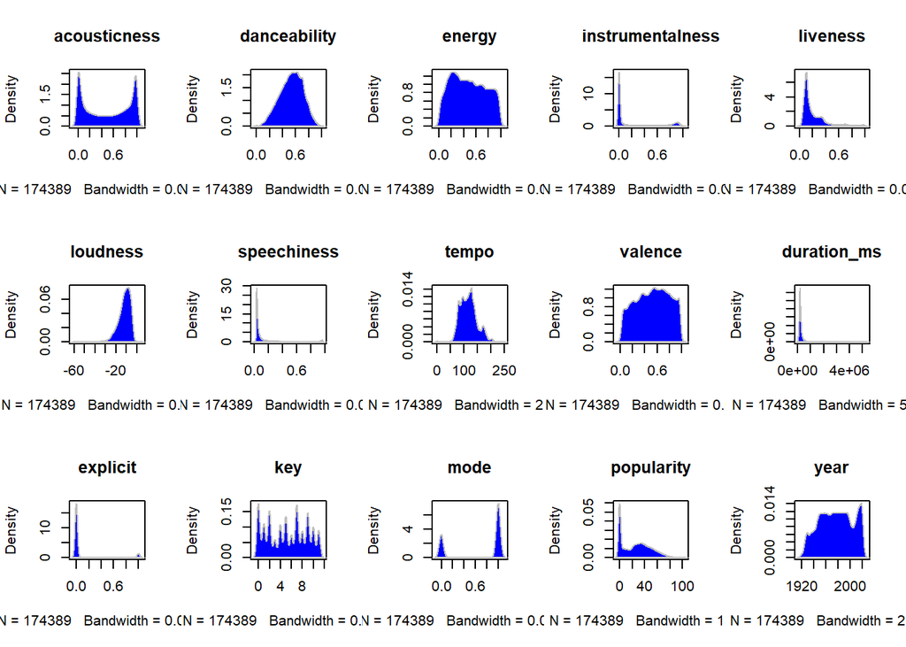

```r
numIntSpotify <- c("acousticness","danceability","energy","instrumentalness","liveness","loudness","speechiness","tempo","valence",
                   "duration_ms","explicit","key","mode","popularity","year")

dfNumSpotify <- spotify[,numIntSpotify]
par(mfrow=c(3,5))
colnames <- dimnames(dfNumSpotify)[[2]]
for (i in 1:15) {
  d <- density(dfNumSpotify[,i])
  plot(d, type = "n", main = colnames[i])
  polygon(d, col="blue",border="gray")
}
```

Here we see the distributions of all of our numeric variables. Most are continuous, however we have a few categorical (mode, key, explicit). Danceability, energy, valence, tempo all seem to follow strong defined estimates of prior distributions, whereas acousticness, loudness, speechiness & liveness are all relatively skewed. We should consider scaling these variables.

```r
normalize <- function(x){
  return ((x - min(x)) / (max(x) - min(x)))
}
spotify$acousticness <- normalize(spotify$acousticness)
spotify$loudness <- normalize(spotify$loudness)
spotify$speechiness <- normalize(spotify$speechiness)
spotify$liveness<-normalize(spotify$liveness)
```

We have now normalized these variables and can look to apply correlation analysis to determine further which variables should be considered within our modelling efforts.

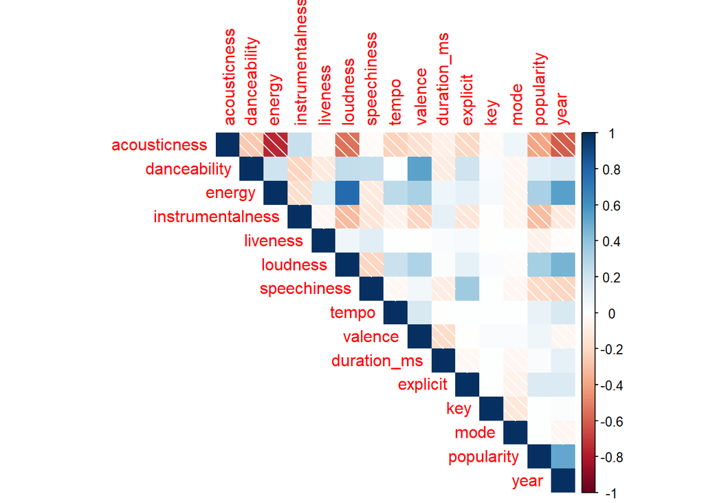

```r
numIntCorr <- cor(spotify[,numIntSpotify])
corrplot(numIntCorr,method="shade", type = "upper")
```

Duration, key, mode seem to have no direct tie with the overall popularity with a song, whereas there is some sembleance of relationship with the other variables included within this analysis.

Off the rip, it looks as if acousticness has a strong neg correlation, while energy & loudness have positive relationships with the popularity of a song on spotify.